# 2020 Q

Jake Cavaiani

11/13/2020

### 2020

2020 (Moose, French, Poker, Vault, Stuart), clean out of water points, potentially erroneous points collected, beaver dams, etc. and prepare to convert to continuous predicted discharge (Q) throuhgout the year.

2020 data is read in from DoD Project->2020 AK sensors->Discharge->Pressure Transducer->“site”

All 2020 water level data except for Poker were calculated with incorrect air pressure data! Here we have redone the rating curves using the raw stream and air pressure sensors (August 2023).

NEON air pressure data to check time zone

## Comparing PTs

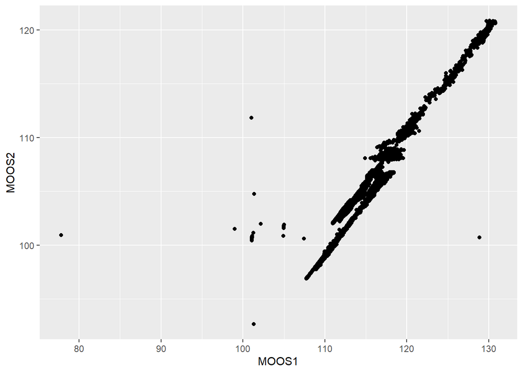

Some erroneous points but not bad. a slight shift

## Comparing FRCH

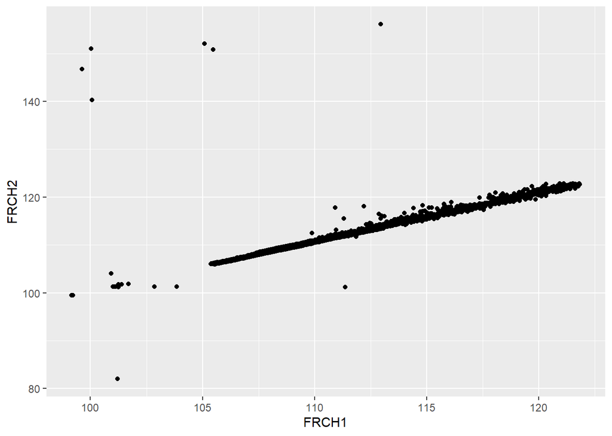

Pretty good, have to clean some of those points

## Comparing Stuart

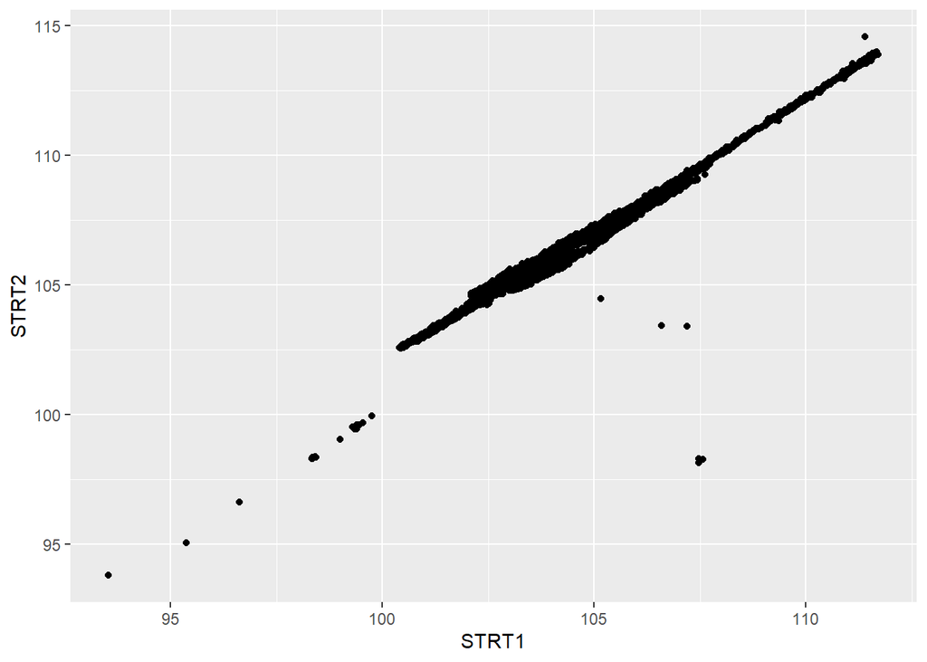

Same as French, some erroneous points that will need to be cleaned

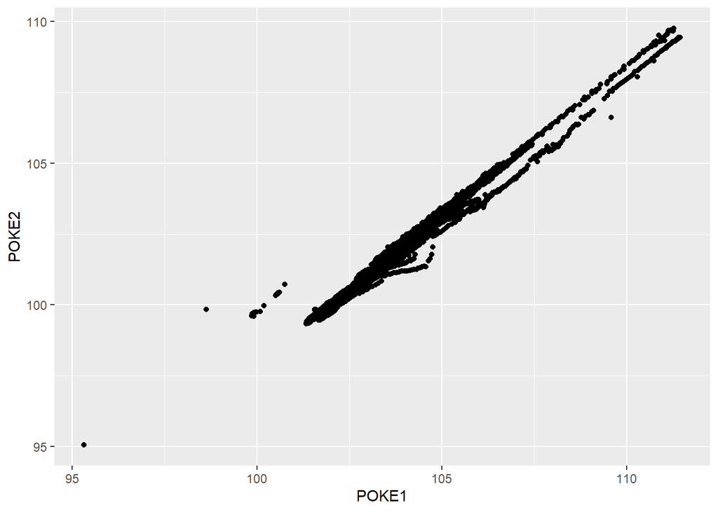

## Observed Discharge at all sites for 2020

Slugs and wading rods were used for 2020 observed Q

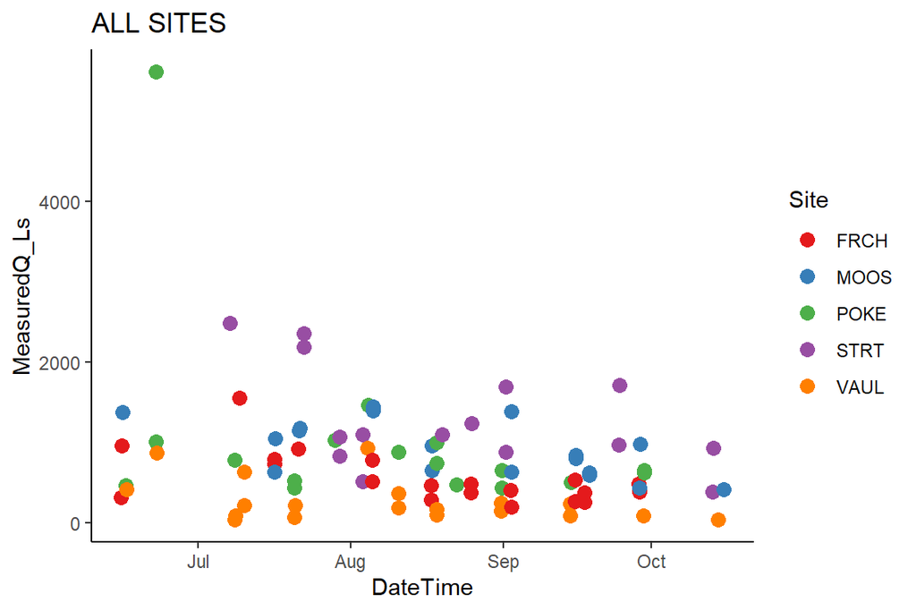

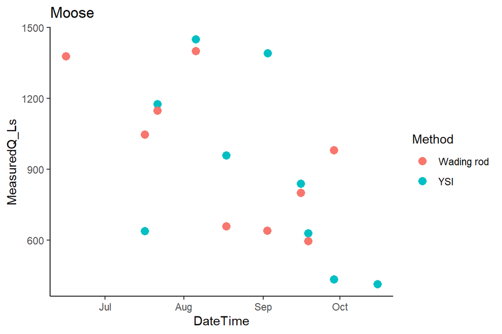

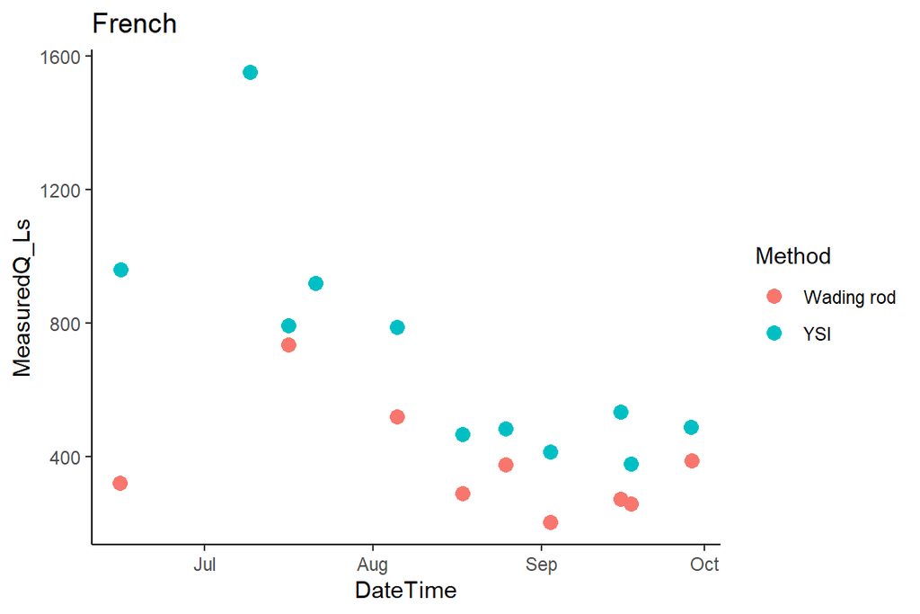

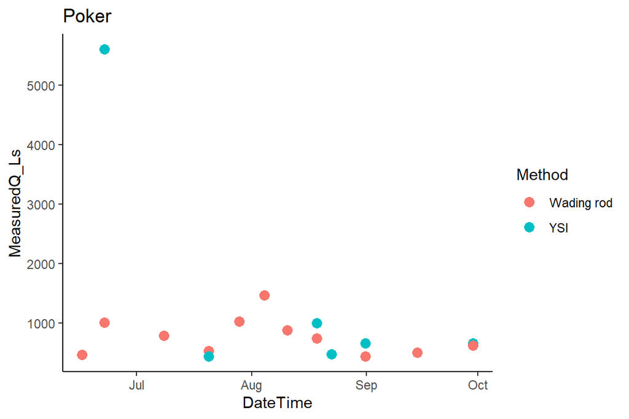

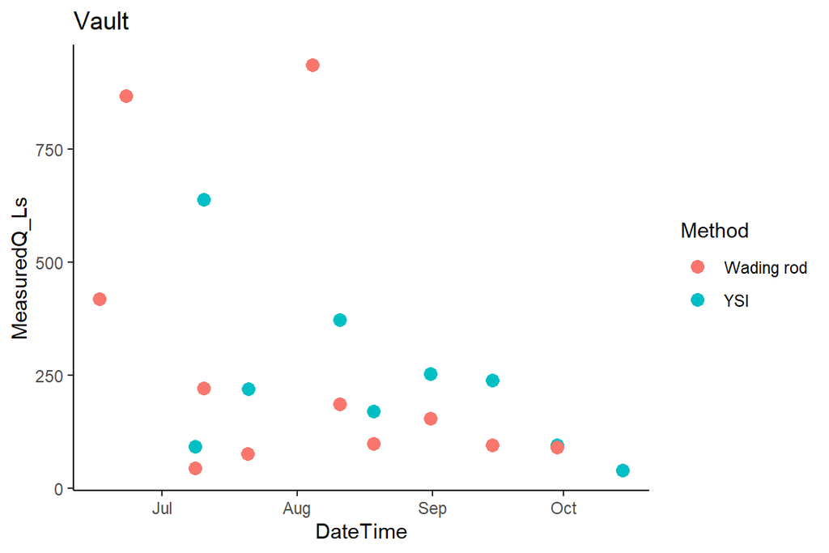

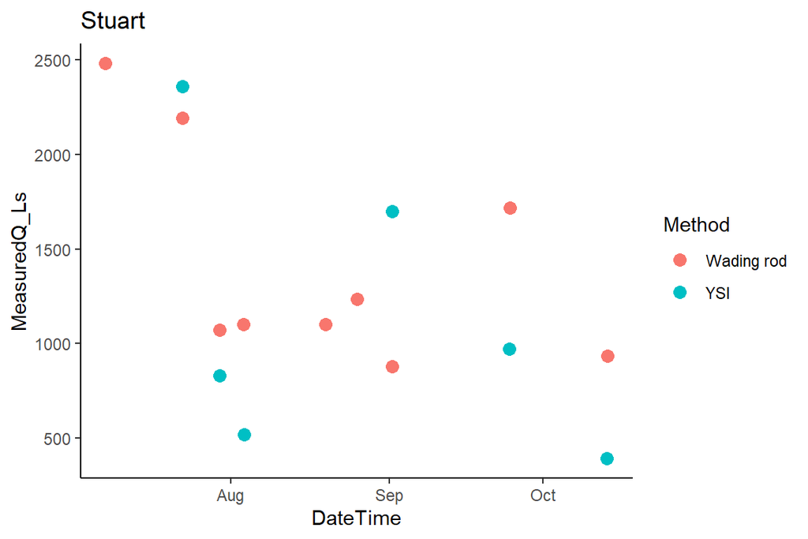

[figure not shown]